# Reproducible Research: Peer Assessment 1

## Loading and preprocessing the data

## download files

```r
fileURL <- "https://d396qusza40orc.cloudfront.net/repdata%2Fdata%2Factivity.zip"
download.file(fileURL, "data.zip")
unzip("data.zip")
activity.data <- read.csv("activity.csv", sep=",", header=TRUE, stringsAsFactors=FALSE)
```

The variables included in this dataset are:

- **steps**: Number of steps taking in a 5-minute interval (missing values are coded as `NA`)
- **date**: The date on which the measurement was taken in YYYY-MM-DD format
- **interval**: Identifier for the 5-minute interval in which measurement was taken

```r
library(xtable)
        headactivity <-xtable(head(activity.data))
        print(headactivity,type="html")
```

|  | steps | date | interval |
| --- | --- | --- | --- |
| 1 |  | 2012-10-01 | 0 |
| 2 |  | 2012-10-01 | 5 |
| 3 |  | 2012-10-01 | 10 |
| 4 |  | 2012-10-01 | 15 |
| 5 |  | 2012-10-01 | 20 |
| 6 |  | 2012-10-01 | 25 |

## What is mean total number of steps taken per day?

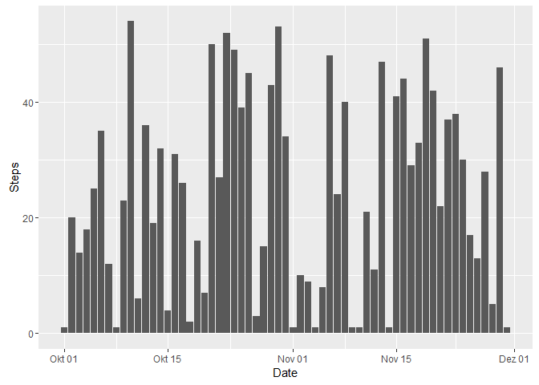

```r
totalsteps <-tapply(activity.data$steps, activity.data$date,sum,na.rm = TRUE)
#convert rownames to column
totalsteps2 <-cbind(rownames(totalsteps),totalsteps)
rownames(totalsteps2) <-NULL
#rename columns
colnames(totalsteps2) <-c("Date","Steps")
# transform the data for analysis
df1<-as.data.frame(totalsteps2)
df1$Date <-as.Date(df1$Date)
df1$Steps <-as.numeric(df1$Steps)
#plot the data
library(ggplot2)
ggplot(df1, aes(x=Date, y=Steps)) +geom_bar(stat="identity")
```

```r
#plot(df1$Date,df1$Steps, type="h")
```

```r
meansteps <- mean(df1$Steps,na.rm=TRUE)
mediansteps <-median(df1$Steps,na.rm=TRUE)
```

## What is the average daily activity pattern?

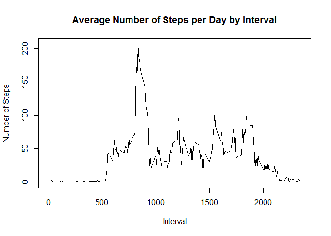

```r
average.steps <-tapply(activity.data$steps, activity.data$interval,mean,na.rm = TRUE)
#convert rownames to column
average.steps2 <-cbind(rownames(average.steps),average.steps)
rownames(average.steps2) <-NULL
#rename columns
colnames(average.steps2) <-c("Interval","Mean.Steps")

# transform the data for analysis
df1<-as.data.frame(average.steps2)
df1$Interval<-as.numeric(df1$Interval)
df1$Mean.Steps <-as.numeric(df1$Mean.Steps)
#plot the data

plot(average.steps2,type="l", xlab="Interval", ylab="Number of Steps",main="Average Number of Steps per Day by Interval")
```

2. Which 5-minute interval, on average across all the days in the dataset, contains the maximum number of steps?

```r
df2 <-df1[which(df1$Mean.Steps == max(df1$Mean.Steps)), ]
library(xtable)
df3 <-xtable(df2)
        print(df3,type="html")
```

[output not shown]

## Imputing missing values

Note that there are a number of days/intervals where there are missing values (coded as `NA`). The presence of missing days may introduce bias into some calculations or summaries of the data.

1. Calculate and report the total number of missing values in the dataset (i.e. the total number of rows with `NA`s)

```r
colSums(is.na(activity.data))
```

```
##    steps     date interval
##     2304        0        0
```

2. Devise a strategy for filling in all of the missing values in the dataset.

The mean of the 5-minute interval is used for the missing values.

3. Create a new dataset that is equal to the original dataset but with the missing data filled in.

```r
new.data <- na.omit(activity.data)

averages <- aggregate(new.data$steps, list(interval = as.numeric(as.character(new.data$interval))), FUN = "mean")
names(averages)[2] <- "Mean.Steps"
act.imp <- activity.data
for (i in 1:nrow(act.imp )) {
        if (is.na(act.imp $steps[i])) {
                act.imp $steps[i] <- averages[which(act.imp $interval[i] == averages$interval), ]$Mean.Steps
        }
}
```

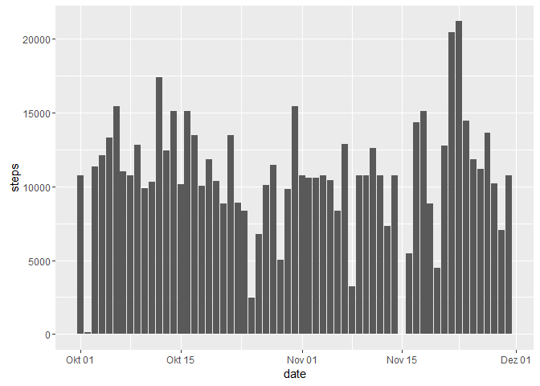

```r
act.imp$date <-as.Date(act.imp$date)
ggplot(act.imp, aes(x=date, y=steps)) +geom_bar(stat="identity")
```

```r
temp <- tapply(act.imp$steps, act.imp$date,sum)
mean.imp <- mean(temp)
median.imp <- median(temp)
```

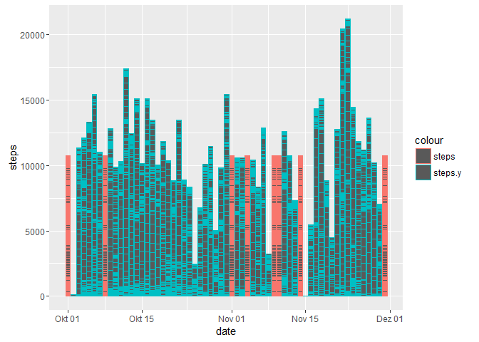

```r
activity.data$date <- as.Date(activity.data$date)
compared.data <- cbind(act.imp,activity.data$steps)
names(compared.data)[4] <- "steps.y"
compared.data <- compared.data[, c("steps","steps.y","date","interval")]
ggplot(compared.data, aes(x=date)) + geom_bar(aes(y=steps,colour="steps"),stat="identity") +geom_bar(aes(y=steps.y, colour="steps.y"),stat="identity")
```

## Are there differences in activity patterns between weekdays and weekends?

1. Create a new factor variable in the dataset with two levels – “weekday” and “weekend” indicating whether a given date is a weekday or weekend day.

```r
activity.data$date <-as.Date(activity.data$date)
activity.data$weekday <- weekdays(activity.data$date)
# German language
library(dplyr)
weekend_list <- c("Samstag","Sonntag")
activity.data2 <- mutate(activity.data, weektime = ifelse(activity.data$weekday %in% weekend_list,"Weekend","Weekday"))

head(activity.data2)
```

```
##   steps       date interval weekday weektime
## 1    NA 2012-10-01        0  Montag  Weekday
## 2    NA 2012-10-01        5  Montag  Weekday
## 3    NA 2012-10-01       10  Montag  Weekday
## 4    NA 2012-10-01       15  Montag  Weekday
## 5    NA 2012-10-01       20  Montag  Weekday
## 6    NA 2012-10-01       25  Montag  Weekday
```

1. Make a panel plot containing a time series plot (i.e. `type = "l"`) of the 5-minute interval (x-axis) and the average number of steps taken, averaged across all weekday days or weekend days (y-axis).

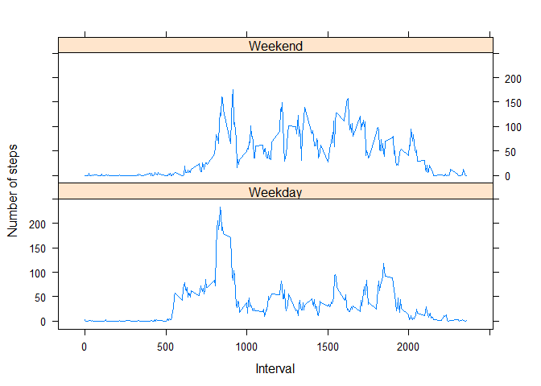

```r
activity.data3 <- aggregate(steps ~ interval + weektime, data = activity.data2, mean)
library(lattice)
xyplot(steps ~ interval|weektime, activity.data3, type = "l", layout = c(1, 2),
       xlab = "Interval", ylab = "Number of steps")
```